# Leveraging partial information across data sets with privacy restrictions: proof of concept for cognitive aging research

Teresa J. Filshtein, Xiang Li, Sarah Ackley, M. Maria Glymour, Melinda C. Power

University of California, San Francisco &

George Washington University

Quick Background

Motivation: Despite promising observational evidence used to motivate randomized control trials (RCTs) for Alzheimer’s disease (AD) prevention, trial results continue to be null.

Goal: Take advantage of recent advances in causal methods and computational tools to close the gap between observational evidence and RCT findings.

Why are we seeing this gap?

Several possible explanations:

1. Publication bias (i.e. observational literature is biased)

2. Suboptimal design in RCT (i.e. too small/short to detect effect, eligibility criteria too restrictive, etc.)

3. Bias in observational studies (i.e. residual confounding or selection bias)

4. Observational research has not provided enough information to anticipate whether a proposed RCT would succeed

And others…

Initial Project

Idea: Data pooling of available observational studies could help bridge the gap

Problem: Privacy restrictions makes full data pooling difficult; many data sets do not include identical variables; sample size (power)/available covariate set are restricted

Project: Proposes a method to leverage partial information across data sets, to make use of publicly (or readily) available summary statistics allowing for construction of simulated data that can be used in lieu of formal data pooling

Proof-of-concept project

Simulate, pool, analyze data from two observational studies:

Unrestricted Dataset: Health & Retirement Study (HRS)

- full access to the data used in our analyses

Restricted Dataset: Atherosclerosis Risk in Communities (ARIC)

- access to publicly available data and readily available information from our team member at GWU.

Motivating research question: Effect of Hemoglobin A1c (HbA1c) on memory loss in aging

Effect of HbA1c on memory decline

- Type 2 diabetes is an established risk factor for dementia
- Chronic hyperglycemia, measured by glycoslyated hemoglobin (HbA1c) is one possible mechanism linking Type 2 diabetes with dementia/memory decline
- A relationship between HbA1c and memory decline has been established, but observational evidence is inconsistent.
- Whether or not glycemic control predicts the risk of memory decline remains uncertain

Two main objectives:

1. Data Generation - recreate the (un)/restricted datasets

Using only summary statistics/readily available information, create synthetic datasets that maintain the underlying causal structure of the data.

2. Pooled Analysis - Analyze data with complete dataset.

Pool together synthetic HRS/ARIC datasets, impute missing covariates across the two sets, analyze final models with complete synthetic data.

The Data

|  | HRS | ARIC |
| --- | --- | --- |
| Count | 11,509 | 12,377 |
| Age | 69 (10) | 58 (5) |
| Memory (standardized) | -0.39 (1.1) | -0.04 (1.01) |
| # Assessments | 3-4 | 4 |
| Follow-up Time | ~8-10yrs | ~20yrs |
| HbA1c | 5.87 (0.97) | 5.81 (1.23) |
| Female | 59% | 55% |
| **Race** |  |  |
| White | 86% | 77% |
| Black | 14% | 23% |
| **Education** |  |  |
| Less Than High School | 21% | 22% |
| High School | 67% | 41% |
| College | 12% | 36% |

Summary of steps

Step 0: Determine causal structure

Draw DAG representing the hypothesized full structural model based on analyses and prior knowledge

Step 1: Generate synthetic HRS data

Step 1a: Estimate joint distributions: Use causal structure as a set of data generating rules to estimate joint distributions in HRS data.

Step 1b: Create synthetic HRS data: Using DAG and estimated joint distributions, generate variables in a step-wise process that maintains causal pathway; create synthetic HRS data sets. Validate.

Summary of steps

Step 2: Generate synthetic ARIC data

Request summary statistics, model fits, effect estimates, from the restricted ARIC dataset. Create synthetic data sets.

Step 3: Pool & Impute

Pool synthetic HRS/ARIC data together, impute missing covariates

Step 4: Analyze

Estimate final model with complete synthetic dataset

Presumed causal structure

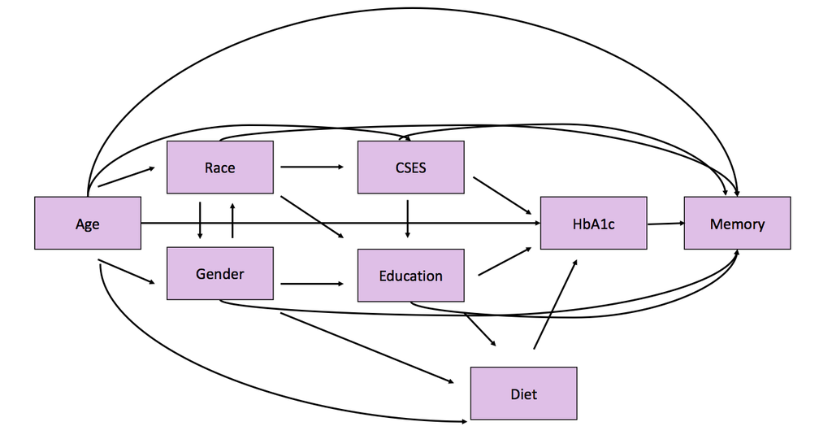

*CSES = childhood socioeconomic status

Presumed causal structure: HRS (blue), ARIC (red)

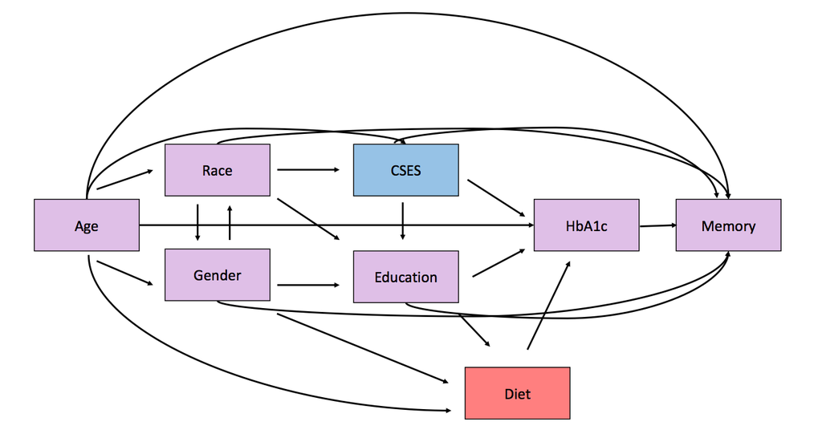

*CSES = childhood socioeconomic status

Step 1: Generate synthetic HRS data

Using the DAG as our guide, the distributions were estimated in the original dataset.

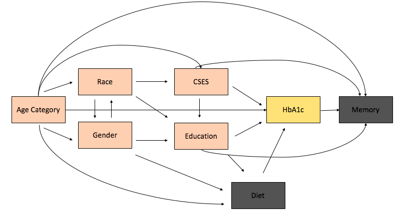

**Age, Race, Gender**

$f(Age, Race, Gender)\sim\text{non-parametric,proportions}$

**CSES**

$f(\text{cses}|\text{Age, Race}): \text{linear model}$  
$\text{random} \sim N(0,\sigma_{cses})$

**Education: Categorical**

$f(\text{educ}|\text{Age, Race, Gender,CSES}): \text{multinomial}$ $\text{random} \sim U(0,1)$

**HbA1c**

$f(\text{HbA1c|Age, Race, Gender,CSES,Educ): gamma}$ $\text{random} \sim G(a_i,b_i)$

**Memory**

$f(\text{Mem|Age, Race, Gender,CSES,Educ,HbA1c): lin. mixed effect, int/slope}$ $\text{random} \sim N(0, \Sigma) + N(0,\sigma_{mem})$

Final Model: Effect of HbA1c on memory decline

Linear mixed effects model, random intercepts/slopes $\text{Memory}_{ij} = \beta_0 + \beta_1\text{Age}_{ij} + \beta_2\text{HbA1c}_{i\lt6.5\%} + \beta_3\text{HbA1c}_{i\geq6.5\%} +$

$\beta_4$$\text{Age}_{ij}*\text{HbA1c}_{i\lt6.5\%}+$ $\beta_5$$\text{Age}_{ij}*\text{HbA1c}_{i\geq6.5\%} +$

$\beta_K\text{Covariates}_i$

The primary interest was the effect of HbA1c on change in memory (slope), $\beta_4,\beta_5$

Step 1: Distribution of Age/Race/Gender - Original vs. Simulated

[figure not shown]

Step 1: Distribution of Age/Race/Gender - Original vs. Simulated

[figure not shown]

Step 1: CSES - Original vs. Simulated

[figure not shown]

Step 1: HbA1c - Original vs. Simulated

[figure not shown]

Results

We compared effect estimates and standard errors under 4 distinct scenarios:

1. Original HRS (ARIC) data/ HRS (ARIC) DAG

2. Synthetic HRS (ARIC) data/ HRS (ARIC) DAG

3.Pooled synthetic HRS and ARIC data with imputed missing variables / Complete DAG

4.Pooled synthetic HRS and ARIC data without imputing missing variables / Reduced DAG

Results: Original (- - -) / Simulated (—)

[figure not shown]

Results: Original (- - -) / Simulated (—)

[figure not shown]

Complications that crept up

Differences in the observation period (e.g. length of observation, number of measurements)

Different types of memory assessments might capture different aspects of decline, standardization might not be enough

We might be missing covariates from both data sets that are confounding the process

In Summary

- This was our first venture down a very long and complicated path.
- Recreating restricted dataset based off of publicly/readily available information is promising.
- We were able to successfully recreate the data in both the (un)restricted sets, however more validation in the future is needed.
- Pooled analyses were more complicated than anticipated, though we’ve learned a lot through the process and are making steps to improve this.

Some next steps

- Incorporating model uncertainty into the data generating process (possibly take a Bayesian approach)
- Replicate with more observational studies

Acknowledgments

Big thanks to Melinda Power, Maria Glymour, Sarah Ackley, and Scott Zimmerman for all their continued help and guidance on this project.

And a huge thanks to Xiang Li . Xiang is a statistics PhD student at George Washington University working with the team there and the ARIC data point person for this project. This work could not have been completed without her!

Memory Trajectory: Effect of HbA1c on Cognitive Decline

[figure not shown]